# Socio-Economic Impact Assessment of Net Pracharat

2/5/2023

## Introduction

The **Village Broadband Internet project** or **Net Pracharat** is a flagship national digital infrastructure development project that aims to **strengthen the broadband network** across the country by establishing high-speed Internet access in every village, especially in rural and remote areas.

## Main Stakeholders

[figure not shown]

Cabinet of Thailand approval (**Dec. 2016**).

## Initial Phase

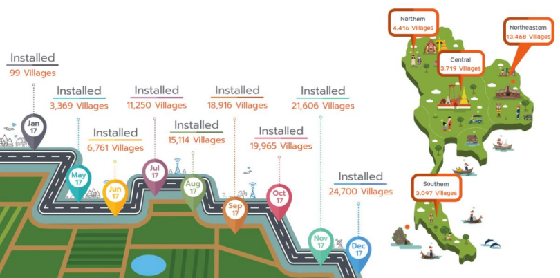

- An initial capital expenditure of **$318 million USD** for the network deployment and installation of Wi- Fi hotspots was funded through the national budget of the government.
- MDES and ToT Public Company completed the **installation of the fibre optic cable networks and free public Wi-Fi hotspots** (one per village) strategically located in public areas and buildings (e.g. schools and temples), with speeds of up to 30/10 Mbps to increase accessibility in **24,700** target rural villages by December 2017.

## Net Pracharat Project Target Area

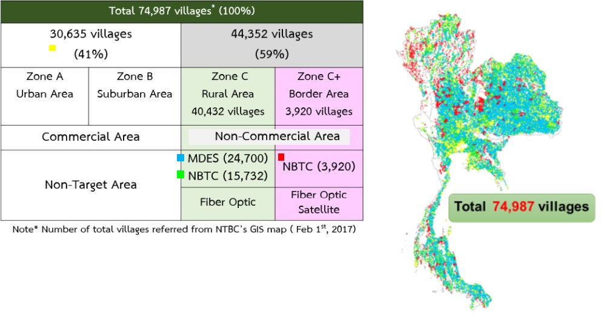

## Steady Progress

[figure not shown]

[figure not shown]

[figure not shown]

## Registered Users (2021)

[figure not shown]

## Objectives

The **Net Pracharat** project aims at **strengthening National Broadband Network** by expanding high-speed Internet networks to reach every village in the country, thereby resulting in bridging the digital divide and building an **inclusive and sustainable connected society**.

## Aims of Net Pracharat Project

In line with “Thailand 4.0” the Net Pracharat Project aims at:

- **Developing high-speed internet networks** via FTTX in each of the targeted villages and efficiently support its future network expansion.
- Provide **free high-speed internet** to people in remote areas to **reduce inequality** and provide **equal access** to government services.
- **Increase the economic and social potential** of target villages to advance careers, incomes, education, public health, agriculture, online-trading and other opportunities.

(*ref*: APT, pg. 15)

Net Precharat aims to impact and transform society, economy, health and education.

## Previous studies/reports

- (June 2021) **Chiang Mai University**, รายงานผลการศึกษาเบื้องต้น(inception) report
- **MDES**, Digital Economy and Society Development Driven Center, The Internet Use of Net Pracharat Villages Report: January to June 2020
- (August 2019) **Asia-Pacific Telecommunity (APT) Report** on Best Practice of Connectivity: Village Broadband Internet Project (Net Pracharat) of Thailand
- Micro-data provided by Survey by **NSO**: (Survey of people’s opinions towards the Pracharat Internet Project 2018)

## NSO Survey (2018)

In July-September 2018, NSO with MDES conducted a field survey to collect villagers’ opinions and satisfaction toward Net Pracharat.

- NSO interviewed 2,577,231 local people in the 24,700 Net Pracharat villages.
- More than 73% of participants recognized benefits of high-speed Internet networks.
- Local people expressed that Net Pracharat helped enhance quality of life for local villagers, provide opportunities for earning a living, generate income supplement, and facilitate the search for useful information related to health, agriculture, and education.
- However, more than 86% thought that more numbers of public Wi-Fi hotspots should be installed throughout their villages.

## Correlation matrix

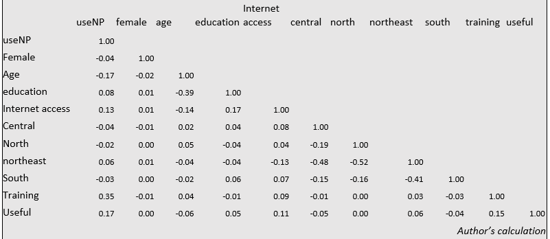

where “useNP” is dummy variable 1 for using Net Precharat Internet (0 otherwise), “female” is 1 for female and 0 male, “age” is age groups (every 5 years), “education” is a 10 group education category, “Internet access” is 1 if have internet access and 0 otherwise, and regions are “central”, “north”, “northeast” and “south”, “training” is 1 if received training for Net Precharat (0 otherwise) and lastly “useful” is 1 if they thought Net Precharat was useful and 0 otherwise.

## Logistic Regression

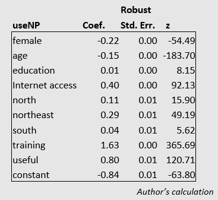

## Internet Use of Net Precharat (Jan - June 2020)

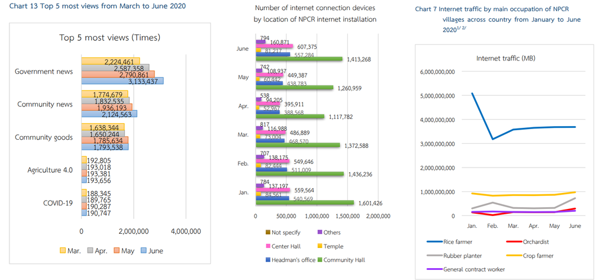

## CMU inception report 2021 (2564)

By May 2021, surveyed 1,598 villages (of which 820 villages were equipped with high-speed internet of the Pracharat internet project).

Those not using were (64.4% female;, 48.9% above 40 years of age; mostly farmers; 67.9% earned income < baht 10K p.m.); About 84% (79.4%) had never used the Internet before (Net Precharat installment); Those not using Net Precharat use mobile internet (65.8%) and fixed-lines (37.6%).

Reason for not using Net Precharat services range from not accessible, far from installation point, to poor signal.

Quantitative Method used in the CMU study:

- Social Accounting Matrix (SAM) & Computable General Equilibrium model (CGE)
- Social Return on Investment (SROI)
- Structural Equation Model (SEM)

## Reason for use of Net Pracharat

- (60.2%) Proximity to installation point (esp. schools)
- (41.4%) Good, fast and consistent signal
- (38.9%) Public events, village funds, meeting in city hall, etc
- (35.9%) Use for entertainment (online games, music, movies, etc)
- (20.4%) Social media, VDO calls, SMS

Opinion:

- While (12.8%) say that Net Pracharat was useful for learning and education.
- High scores were registered for convenient, free, easy to use, register for public services (esp. during Covid-19), help create opportunities, help reduce digital divide by improving digital literacy and media, access to news, etc
- Moderate scores for helping to be closer to friends, relatives, creating digital content and revenue generation fro publishing on the internet, etc. and very low scores for potential to provide new way of life/values, and make meaningful impact in future lives
- Problems remain in distinguishing true and fake information.
- Internet access still a problem in areas esp. Northeast region of Thailand.

## Effectiveness Assessment

1. Access to telecommunications services: Vast majority of Internet users are students (2/3)
2. Access to information (equally): High scores for helping to enhance careers, income, education, access to public health, agriculture and online trading. Moderate scores for stimulating ideas for solving problems in new ways or the creation of new ideas.
3. Reducing the digital divide: 78-80% in remote/marginal areas use Net Precharat services (of which 15-18% rely solely on Net Precharat for Internet access).
4. USO Net service (access in remote/marginal areas): High scores for convenience, free access, access to government services, information, etc.

The CMU study further calculates **Net Present Value (NPV)** and the **Benefit-Cost Ratio (B/C Ratio)** (by considering only economic benefits) and concludes that there is **no** positive payback on investment as of June 2021. However this is to be expected, since the project is not designed for profit.

The **Internal Rate of Return (IRR)** was calculated to be 62.04% (for the case when positive NPV are expected, i.e., when there are Net Pracharat users exceeding 600,000 persons/day).

**Cost-effective analysis** was also carried out which employed 4 further indicators: New Users Per Investment (NUPI), Better Quality Per Investment (BQPI), Total Access Per Investment (TAPI), and Digital Divide Alleviation (DDA).

## Social Accounting Matrix (SAM) & Computable General Equilibrium (CGE) simulation

Overall the SAM and CGE point to **positive** economic impact of Net Pracharat and USO projects.

The SAM and CGE measure (1) the total effect from investment (direct, indirect, induced), (2) benefits on the economic sector, (3) benefits on households from income distribution, (4) nominal/real GDP growth rate and value, and (5) benefits from tax collection.

Direct benefits were estimated at Baht 1.36 mil. (indirect effects were 4 times larger than direct effects); lowest income groups would benefit 40% increase in incomes; Net Pracharat contributes 1.81 % to nominal GDP; additional direct tax collection of Baht 45,610 million Baht, etc.

## Other methods

### Social Return on Investment (SROI) method

In addition, the SROI, by considering social returns in addition to economic benefits, finds that with 400,000 users per day, capital payback period would be reached by 2022 (c.f for ROI, 1.07 mil. users are required).

### Structural Equation Modelling (SEM)

Further impact of Net Precharat and USO were confirmed using SEM.

- The total economic impact was estimated at 0.015-0358% from NEt Pracharat (USO) project.
- Social impact were related positively to higher income, no prior internet usage/experience, but; negatively related to elderly, lack of ability to access information, distinguishing fake information, lack of ideas in solving problems, etc.

### Interview with Expert

November 12, 2020 (1:00 - 4:00 PM) Ms. Piyada Sudkangwan, Director of the Center for Digital Development Drive. for the Economy and society Ministry of Digital Economy.

## What Next?

Moving forward, a comprehemsive socio-economic assessment for Net Precharat should use mixed-method:

- **Quantitative studies**
  - Difference-in-Difference
  - Propeensity Score Matching
  - Update on CMU data/survey
- **Qualitative (focus group) study**
  - Interview/questionnaire

The assessment (incl. updating data, conducting survey, meetings with stakeholders, data analysis and report writing) should take 2-3 months.

## Interview with Stakeholders/Village

MDES, TOT, NBTC, Ministry of Interior, Village leaders, etc.

1. Main objective(s) that Net Pracharat should address.
2. Are they technologically capable of providing sufficient broadband capacity to all villages to allow Net Pracharat targets to be met?
3. Would it be financially viable for private network operators to provide connectivity via new rural terrestrial wireless broadband technologies?
4. What economic and social benefits could potentially be obtained by authorizing these technologies?
5. What are expected additional revenues for villagers, which sets a target of offering broadband access to rural users?
6. How often does MDES conduct activities such as (a) promoting local community business to become E-Commerce villages, (b) expand Net Pracharat Volunteer network, (c) form provincial Net Pracharat caretakers, and (d) organize Net Pracharat Village Model contest.
7. What are the objectives and expected benefits of activities in (6) above?

Further questions to capture impact/benefits of Net Pracharat for **users** (and **non-users**) in selected villages.

## Quantitative Studies

**Difference-in-difference** and propensity score matching are standard policy evaluation tools in the literature.

### Difference-in-difference

Measure socio-economic impact using village level data on pre- and post-Net Pracharat installment periods, for areas having access to Net Precharat (a.k.a treatment group) and areas without access to Net Pracharat (a.k.a control group). A direct comparison of means of socio-economic indicators and/or though regression analysis may be employed to quantify possible impact of Net Precharat

\[ \begin{aligned} \text{socio-economic indicator} &= \alpha + \beta_1 Dummy^{post} + \beta_2 Dummy^{treatment} \\ &= + \gamma (\beta_1 Dummy^{post} \times Dummy^{treatment}) + \sum_{k} \phi_{k} Controls_k + \epsilon \\ \end{aligned} \] We will read off and interpret the coefficiant of interaction variable \(\gamma\).

### (Propensity score matching)

Depending on data, PSM may help us confirm some of the results.

## Why Difference-in-difference?

[output not shown]

## Time-line

| SPECIFICS | Month 1 | Month 1 | Month 2 | Month 2 | Month 3 |
| --- | --- | --- | --- | --- | --- |
| Setup, pre-operations, and planning | 20 days |  |  |  |  |
| Finalization of socio-economic assessment framework and tools | 20 days |  |  |  |  |
| Stakeholder meetings, interviews |  | 10 days | 20 days |  |  |
| Field survey (selected villages), focus group interviews |  |  | 20 days | 10 days |  |
| Data analysis, prepare reports and presentations |  |  |  | 10 days | 20 days |

## References

- APT Report on Best Practice of Connectivity (2019) Village Broadband Internet Project (Net Pracharat) of Thailand, Asia-Pacific Telecommunity.
- Chiang Mai University (2021) รายงานผลการศึกษาเบ้ืองตน(Inception Report)
- Gertler, Paul J., Martinez, S., Premand, P., Rawlings, L.B., Vermeersch, C.M.J.. (2016). Impact Evaluation in Practice, Second Edition.
- International Telecommunication Union (2020). The Last-mile Internet Connectivity Solutions Guide. ITU Publications
- Ministry of Digital Economy and Society (2020). The Internet Use of Net Pracharat Villages Report: January to June 2020. Thailand Digital Economy and Society Development Plan.
- Office of the National Economic and Social Development Board (2018). National Strategy 2018- 2037 (Summary). Bangkok: National Strategy Secretariat Office, Office of the National Economic and Social Development.
- Prasertpakdi, N. (2018). Saan Palang Pracharat [Collaborate Pracharat Power]. Bangkok: The Secretariat of The House of Representatives Print.
- Rekha, J. (2016). “Measuring the perceived impact of Internet on individuals in rural India”. Working Paper-Indian Institute of Management, Ahmedabad (2016-03-61).
- Saan Palang Pracharat [Collaborate Pracharat Power]. Bangkok: The Secretariat of The House of Representatives Print.